# Visualisation

Ning Yilin

Last update on 2016-12-12

[top] [[Back to index]](https://github.com/nyilin/My-R-help-sheets)

# Choosing Colours for Visualisation

The choice of colour is important in visualisations. [ColorBrewer](http://colorbrewer2.org/) is a good website to choose colours for both qualitative and quantitative data.

Colours are specified using HEX values in R by default. There are also more than 100 colours in R that have meaningful names. For example, colour `#FF8C00` is named `darkorange` in R. The most commonly used colours, such as black, red, green and blue, can also be referred to by numbers 1 to 4.

R also implements RGB colour specification with function `rgb`. Function `col2rgb` converts R colour to RBG values. For example, colour `darkorange` is red = 255, green = 140, blue = 0 using RGB specification. These two functions are also members of the `grDevices` package.

With newer version of RStudio, we can also use Addin `Colour Picker` to choose colour conveniently.

The ways of choosing colours mentioned above are convenient when only a few colours are needed. When colours are to be used to represent larger numbers of categories, or when we intend to use gradually changing colours to represent quantitative data, it is easier to use methods bellow.

There are several R functions that could generate colour for quantitative data.

### Rainbow

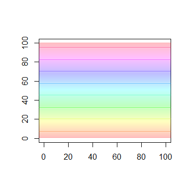

```r
len <- 100
plot(0, type = "n", xlim = c(0, len), ylim = c(0, len), xlab = "", ylab = "")
abline(h = 1:len, col = rainbow(len, alpha = 0.5))
```

## Gradually Changing Colour

Function `colorRampPalette` generates a vector of colours gradually changing from the first colour in the input to the second.

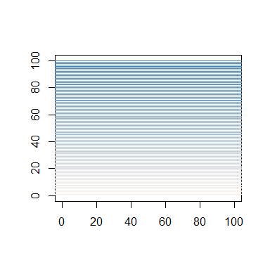

```r
plot(0, type = "n", xlim = c(0, len), ylim = c(0, len), xlab = "", ylab = "")
abline(h = 1:len, col = colorRampPalette(c("seashell", "steelblue"))(len))
```

## Heat colour

Function `heat.colors` generates a vector of heat colours, i.e. colour gradually changing from red to yellow.

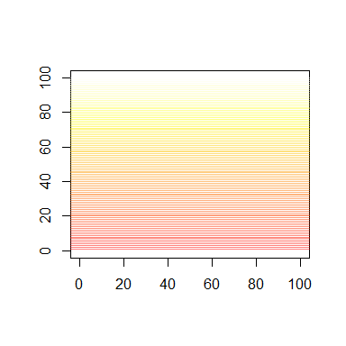

```r
plot(0, type = "n", xlim = c(0, len), ylim = c(0, len), xlab = "", ylab = "")
abline(h = 1:len, col = heat.colors(len, alpha = 0.5))
```

## Other Pre-defined Colour Schemes

### `terrian`

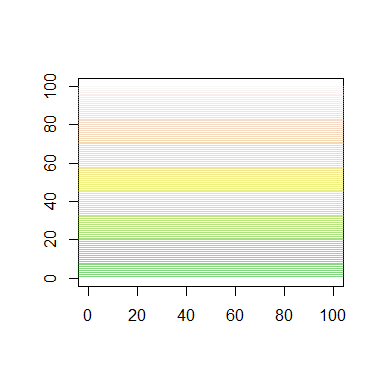

```r
plot(0, type = "n", xlim = c(0, len), ylim = c(0, len), xlab = "", ylab = "")
abline(h = 1:len, col = terrain.colors(len, alpha = 0.5))
```

### `topo`

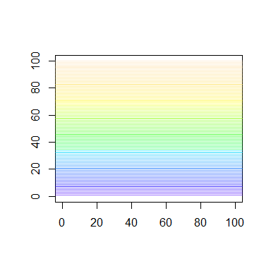

```r
plot(0, type = "n", xlim = c(0, len), ylim = c(0, len), xlab = "", ylab = "")
abline(h = 1:len, col = topo.colors(len, alpha = 0.5))
```

### `cm`

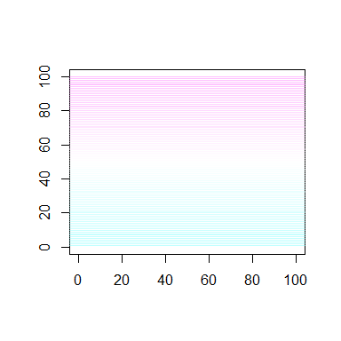

```r
plot(0, type = "n", xlim = c(0, len), ylim = c(0, len), xlab = "", ylab = "")
abline(h = 1:len, col = cm.colors(len, alpha = 0.5))
```

# Commonly Used Parameters

Parameters listed here are commonly used in plotting, and also applies to different plotting engines like `plot`, `grid` and `ggplot`.

## Point Characters

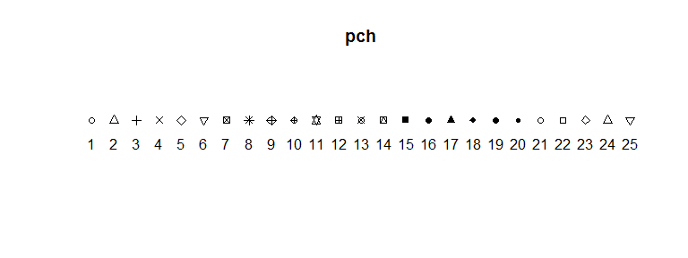

```r
plot(x = 1:25, y = numeric(25), pch = 1:25, main = "pch", xlab = "", ylab = "",
     axes = FALSE, ylim = c(-0.5, 0.5))
text(x = 1:25, y = rep(-0.25, 25), labels = 1:25)
```

## Transparency

### Transparency for Contiguous Colours

Parameter `alpha` is available in all the contiguous colour functions, and controls the transparency of colours generated. The default value is 1 (opaque), and can be as low as 0 (invisible).

### Transparency for A Single Colour

Function `adjustcolor` in package `grDevices` (loaded by default) can be used to adjust the transparency of colour, ranging from 1 (opaque) to 0 (invisible).

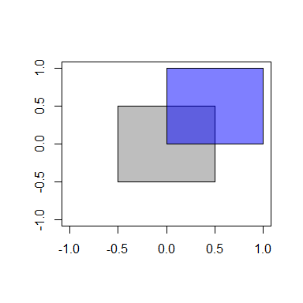

```r
plot(0, type = "n", xlim = c(-1, 1), ylim = c(-1, 1), xlab = "", ylab = "")
polygon(c(-0.5, 0.5, 0.5, -0.5), c(-0.5, -0.5, 0.5, 0.5), col = "gray")
polygon(c(0, 1, 1, 0), c(0, 0, 1, 1), col = adjustcolor("blue", alpha.f = 0.5))
```

# Special Characters in Plots

R can plot special characters and expressions with the help of function `expression`.

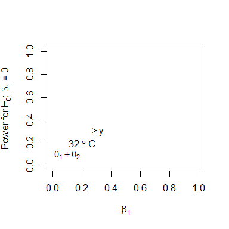

```r
plot(0, type = "n", xlim = c(0, 1), ylim = c(0, 1),
     xlab = expression(beta[1]),
     ylab = expression(paste("Power for ", H[0], ": ", beta[1], " = 0")))
text(x = 0.1, y = 0.1, expression(theta[1] + theta[2]))
text(x = 0.2, y = 0.2, expression(32~degree~C))
text(x = 0.3, y = 0.3, labels = expression('' >= y))
```

```r
# expression('' >= y >= z) does not work
```

# Using `plot`

## Axis and Labels

Parameter `axes` can be used to remove axes and the box surrounding the plot. However, with the box removed, axes added to the plot look a bit wierd.

Function `axis` adds axes to plots. Note that parameter `las` controls the direction of axes labels, with `1` for horizontal and `3` for vertical. Other values are not implemented.

Function `mtext` can be used to add text right beside axes outside of the plotting region. Parameter `las` works the same way in this function.

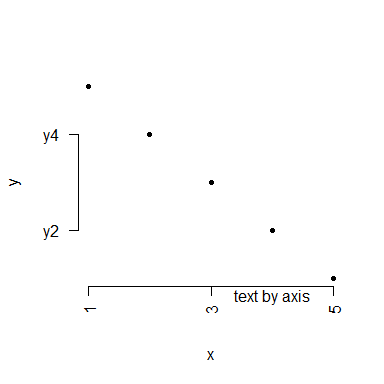

```r
plot(x = 1:5, y = 5:1, pch = 20, axes = FALSE, xlab = "x", ylab = "y")
axis(side = 1, at = c(1, 3, 5), las = 3)
axis(side = 2, at = c(2, 4), labels = paste0("y", c(2, 4)), las = 1)
mtext(text = "text by axis", side = 1, at = 4, las = 1)
```

To remove axes but keep the box and hence make the user-defined axes look better, use `xaxt` and `yaxt` instead. Note that `n` should be used instead of `FALSE`.

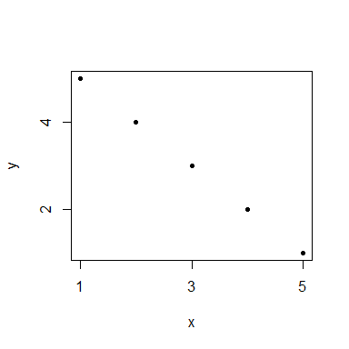

```r
plot(x = 1:5, y = 5:1, pch = 20, xaxt = "n", yaxt = "n", xlab = "x", ylab = "y")
axis(side = 1, at = c(1, 3, 5))
axis(side = 2, at = c(2, 4))
```

```r
# text(x = xposition, y = yposition, text_to_add)
```

## Text

Function `text` can be used to add text at any position in a plot.

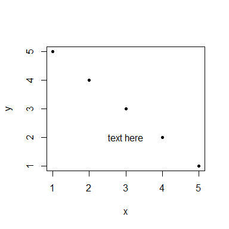

```r
plot(x = 1:5, y = 5:1, pch = 20, xlab = "x", ylab = "y")
text(x = 3, y = 2, labels = "text here")
```

## Legend

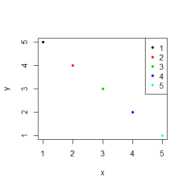

```r
plot(x = 1:5, y = 5:1, pch = 20, col = 1:5, xlab = "x", ylab = "y")
legend("topright", legend = 1:5, col = 1:5, pch = rep(20, 5))
```

## Polygon

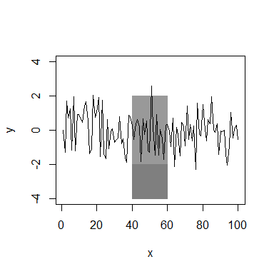

```r
x <- 1:100
y <- rnorm(100)
plot(0, type = "n", xlim = c(1, 100), ylim = c(-4, 4), xlab = "x", ylab = "y")
polygon(x = c(40, 60, 60, 40), y = c(-2, -2, 2, 2),
        col = "gray60", border = "gray60")
polygon(x = c(40, 60, 60, 40), y = c(-4, -4, -2, -2),
        col = "gray50", border = "gray50")
lines(x = x, y = y)
```

## Two-Dimentional Kernel Density Plots

Contour plots are based on two-dimensional density functions, which can be calculated using function `kde2d` from package `MASS`.

Function `contour` plots contour plot for two-dementional kernel density.

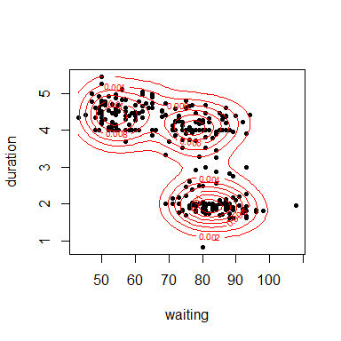

```r
library(MASS)
attach(geyser)
den <- kde2d(geyser$waiting, geyser$duration, n = 50)
plot(x = geyser$waiting, y = geyser$duration, pch = 20, xlab = "waiting",
     ylab = "duration")
contour(x = den, add = TRUE, col = "red")
```

Function `pairs` plots pairwise scatter plots for all the variables, continuous or discrete, in a given matrix or data.frame. The functions for plots in the upper and lower pannels can be user-specified so that they display more information than mere scatter plots.

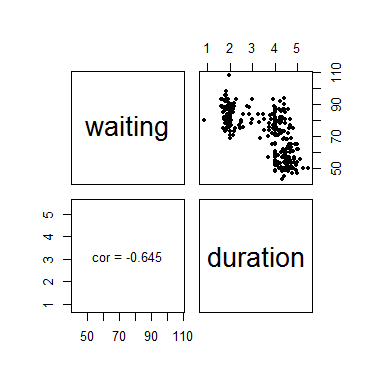

```r
pairs(geyser,
      upper.panel = function(x, y) {
        points(x = x, y = y, pch = 20)
      },
      lower.panel = function(x, y) {
        r <- cor(x, y, method = "pearson")
        text(x = mean(range(x, na.rm = TRUE)),
             y = mean(range(y, na.rm = TRUE)),
             labels = sprintf("cor = %.3f", r))
      })
```